# Projet Fierthé

## 2. Statistiques Descriptives (suite)

### Analyse des Emballages

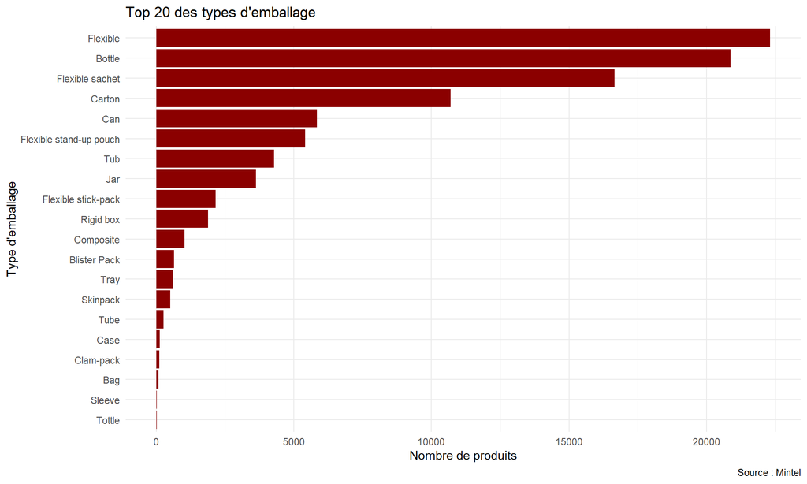

```r
# Top 20 des types d'emballage
df %>%
  filter(!is.na(`Package Type`)) %>%
  count(`Package Type`, sort = TRUE) %>%
  slice_max(n, n = 20) %>%
  ggplot(aes(x = reorder(`Package Type`, n), y = n)) +
  geom_col(fill = "darkred") +
  coord_flip() +
  labs(title = "Top 20 des types d'emballage",
       x = "Type d'emballage",
       y = "Nombre de produits",
       caption = "Source : Mintel") +
  theme_minimal()
```

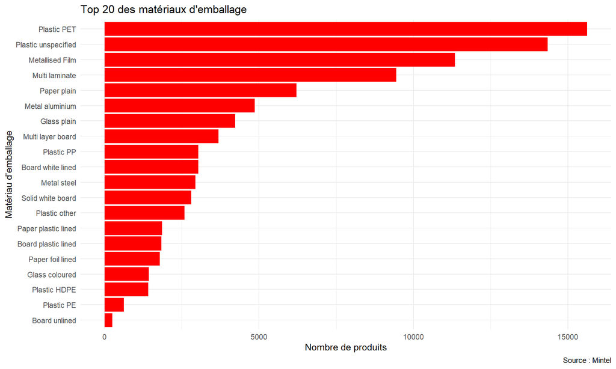

```r
# Top 20 des matériaux d'emballage
df %>%
  filter(!is.na(`Package Material`)) %>%
  count(`Package Material`, sort = TRUE) %>%
  slice_max(n, n = 20) %>%
  ggplot(aes(x = reorder(`Package Material`, n), y = n)) +
  geom_col(fill = "red") +
  coord_flip() +
  labs(title = "Top 20 des matériaux d'emballage",
       x = "Matériau d'emballage",
       y = "Nombre de produits",
       caption = "Source : Mintel") +
  theme_minimal()
```

## 2. Statistiques Descriptives (suite)

### Prix selon le Type d’Emballage

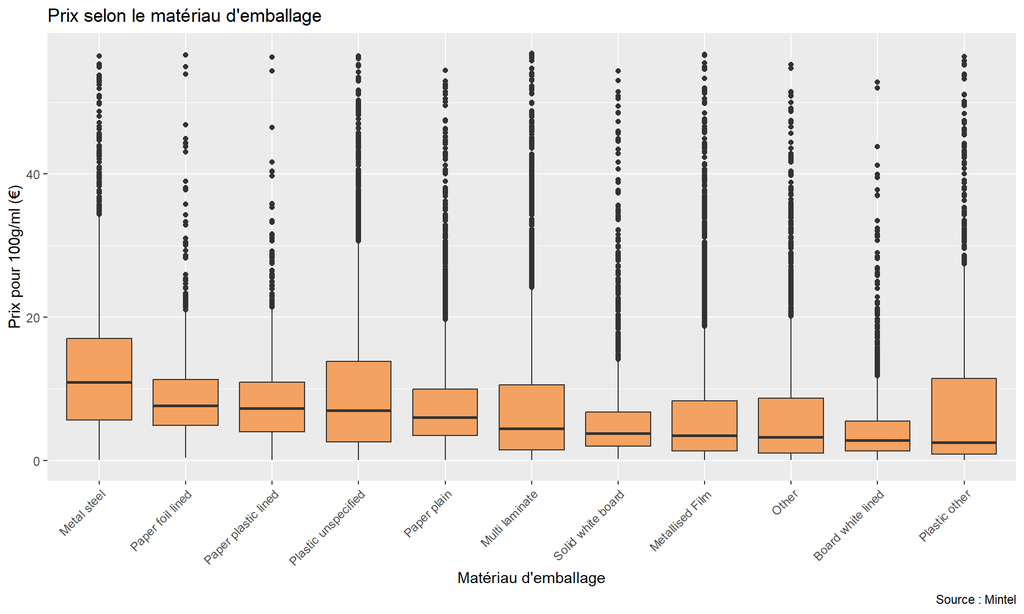

```r
# Prix selon le matériau d'emballage
df_tea %>%
  filter(!is.na(`Package Material`),
         `Price per 100 g/ml in Euros` <= quantile(`Price per 100 g/ml in Euros`, 0.99, na.rm = TRUE)) %>%
  ggplot(aes(x = fct_reorder(fct_lump(`Package Material`, 10),
                           `Price per 100 g/ml in Euros`,
                           .fun = median,
                           .desc = TRUE),
             y = `Price per 100 g/ml in Euros`)) +
  geom_boxplot(fill = "#f4a261") +
  labs(title = "Prix selon le matériau d'emballage",
       x = "Matériau d'emballage",
       y = "Prix pour 100g/ml (€)",
       caption = "Source : Mintel") +
  theme(axis.text.x = element_text(angle = 45, hjust = 1))
```

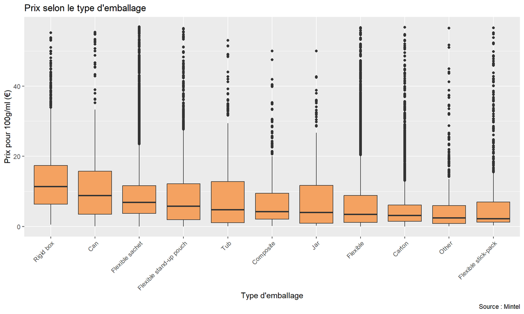

```r
# Prix selon le type d'emballage
df_tea %>%
  filter(!is.na(`Package Type`),
         `Price per 100 g/ml in Euros` <= quantile(`Price per 100 g/ml in Euros`, 0.99, na.rm = TRUE)) %>%
  ggplot(aes(x = fct_reorder(fct_lump(`Package Type`, 10),
                           `Price per 100 g/ml in Euros`,
                           .fun = median,
                           .desc = TRUE),
             y = `Price per 100 g/ml in Euros`)) +
  geom_boxplot(fill = "#f4a261") +
  labs(title = "Prix selon le type d'emballage",
       x = "Type d'emballage",
       y = "Prix pour 100g/ml (€)",
       caption = "Source : Mintel") +
  theme(axis.text.x = element_text(angle = 45, hjust = 1))
```

## 3. Préparation des Données

### Création des Variables Claims

```r
# 1. Santé & Bien-être
claims_sante <- c(
  "Functional - Energy","Functional - Other","Functional - Brain & Nervous System","Functional - Digestive","Functional - Immune System","Antioxidant","Functional - Bone Health","Functional - Skin, Nails & Hair","Functional - Cardiovascular","Probiotic","Functional - Stress & Sleep(5)
Water Resistant","Functional - Weight & Muscle Gain","Functional - Beauty Benefits","Functional - Eye Health","Functional - Slimming","High Satiety","Prebiotic","Anti-Bacterial","Anti-Perspirant","Breath-Freshening","Cleansing","Exfoliating","Homeopathic","Long-Lasting","Odour Neutralising","Protects Against Elements","UV Protection","Waterproof","No Added Sugar","Low/Reduced Sugar","Sugar Free","Low/No/Reduced Calorie","Low/No/Reduced Carb","Low/No/Reduced Sodium","Diet/Light","Low/No/Reduced Fat","Low/No/Reduced Cholesterol","Low/No/Reduced Glycemic","Low/No/Reduced Saturated Fat","Low/No/Reduced Transfat","Low/Reduced Alcohol","Not Pasteurised","High/Added Fibre","Vitamin/Mineral Fortified","High/Added Protein",
"Added Calcium","Stanols/Sterols","Low/No/Reduced Allergen","Low/No/Reduced Lactose","Diabetic",
  # Product tested:
  "Dermatologically Tested","Allergy Tested","For Balanced Skin","For Combination Skin","For Dry Skin","For Oily Skin","For Sensitive Skin","For Sensitive","Teeth/Gums","Hypoallergenic","Non-Acnegenic","Non-Comedogenic","Ophthalmologically Tested","Skin Disorders","Skin Disorders - Dermatitis","Skin Disorders - Diaper Rash","Skin Disorders - Eczema","Skin Disorders - Psoriasis","Skin Disorders - Warts",
## beauté :
"Anti-Ageing","All Skin Tones","Anti-Acne","Anti-Cellulite","Anti-Dandruff","Anti-Hairloss","Brightening / Illuminating","Collagen Increasing","Damaged Hair","Firming","Gradual Self-Tanning","Mattifying","Moisturising / Hydrating","Plumping","Reduces Dark Circles / Puffiness","Reduces Fine Lines / Wrinkles","Reduces Redness","Reduces the Appearance of Pores","Slimming","Toning","Whitening"
)

# 2. Naturalité & Propreté
claims_naturel <- c(
"Botanical/Herbal","All Natural Product","GMO Free","No Additives/Preservatives",
"Free from Added/Artificial Preservatives","Free from Added/Artificial Colourings","Free from Added/Artificial Flavourings","Free from Added/Artificial Additives","Wholegrain","Aromatherapy","Dairy Free","Alcohol Free","Hormone Free","Caffeine Free","Palm Oil Free","Fragrance Free","Grain Free","Mineral","Oil/Petroleum Free","Oil Free","Paraben Free","pH Balanced","Silicone Free","Sulphate/Sulfate Free"
)

# 3. Ciblage & Besoins Spécifiques
claims_ciblage <- c(
  # Demographie
  "Children (5-12)", "Babies & Toddlers (0-4)",
  "Female", "Male", "Maternal", "Seniors (aged 55+)","teenagers (13-17)",
  "Ethnic",
  # COnviens pour
  "Vegetarian", "Vegan/No Animal Ingredients", "Gluten Free","Low/No/Reduced Lactose",  "Kosher", "Halal", "Diabetic", "Diet/Light","Low/No/Reduced Allergen",
  "Plant Based",
  # cyblage animaux
  "Anti-Parasite","Functional Pet - Brain & Nervous System","Functional Pet - Digestion","Functional Pet - Eyesight","Functional Pet - Heart & Cardiovascular System","Functional Pet - Immune System","Functional Pet - Joints, Bones & Muscles","Functional Pet - Other","Functional Pet - Skin & Coat","Functional Pet - Slimming","Functional Pet - Teeth & Tartar Prevention","Functional Pet - Urinary Tract","Functional Pet - Weight & Muscle Gain","Pet - Adult","Pet - Junior","Pet - Senior"
)

# 4. Éthique
claims_ethique <- c(
  "ethical - human", "ethical - charity", "ethical - animal", "ethical",
  "fair trade", "equitable", "social responsibility"
)

# 5. Bio
claims_bio <- c(
  "organic", "bio", "biologique", "non-GMO","GMO Free",
  "pesticide-free"
)

# 6. Environnement
claims_environnement <- c(
  "ethical - environmentally friendly package", "ethical - recycling",
  "ethical - sustainable (habitat/resources)", "ethical - toxins free",
  "ethical - biodegradable", "carbon neutral", "biodegradable packaging",
  "sustainable", "recyclable", "compostable", "eco-friendly", "zero waste"
)

# 7. Packaging & Convenience
claims_strategie <- c(
  "convenient packaging", "time/speed", "ease of use", "interesting packaging",
  "microwaveable", "refill/refillable", "portionability", "on-the-go",
  "biodegradable packaging","premium", "social media", "seasonal", "limited edition","Personalised Formulation","Innovative Ingredient","Doctor Brand",
  "event merchandising", "novel", "cobranded","economy","Wholegrain"
)

# Fonction pour détecter la présence d'un mot-clé
detect_claim <- function(text, keywords) {
  if (is.na(text)) return("non")
  any(str_detect(text, fixed(keywords, ignore_case = TRUE))) %>% ifelse("oui", "non")
}

# Créer les colonnes
df <- df %>%
  mutate(
    claim_sante = map_chr(`Positioning Claims`, ~ detect_claim(.x, claims_sante)),
    claim_naturel = map_chr(`Positioning Claims`, ~ detect_claim(.x, claims_naturel)),
    claim_ethique = map_chr(`Positioning Claims`, ~ detect_claim(.x, claims_ethique)),
    claim_strategie = map_chr(`Positioning Claims`, ~ detect_claim(.x, claims_strategie)),
    claim_ciblage = map_chr(`Positioning Claims`, ~ detect_claim(.x, claims_ciblage)),
    claim_bio = map_chr(`Positioning Claims`, ~ detect_claim(.x, claims_bio)),
    claim_environnement = map_chr(`Positioning Claims`, ~ detect_claim(.x, claims_environnement))
  )

rm(claims_ciblage,claims_ethique,claims_naturel,claims_sante,claims_strategie,
   claims_environnement,claims_bio,detect_claim)
```

## 3. Préparation des Données

### Catégorisation des Emballages et Variables Économiques

```r
# Categorisation des matériaux packages
df <- df %>%
  mutate(material_group = case_when(
    str_detect(`Package Material`, regex("Plastic", ignore_case = TRUE)) ~ "Plastique",
    str_detect(`Package Material`, regex("Paper|Board", ignore_case = TRUE)) ~ "Papier / Carton",
    str_detect(`Package Material`, regex("Glass", ignore_case = TRUE)) ~ "Verre",
    str_detect(`Package Material`, regex("Metal|Metallised", ignore_case = TRUE)) ~ "Métal",
    str_detect(`Package Material`, regex("Wood|Pulp|Corrugated", ignore_case = TRUE)) ~ "Bois",
    str_detect(`Package Material`, regex("foil|lined|multi", ignore_case = TRUE)) ~ "Composites",
    is.na(`Package Material`) | `Package Material` == "Miscellaneous" ~ "Non spécifié",
    TRUE ~ "Autre"
  ))

df <- df %>%
  mutate(package_group_type = case_when(
    str_detect(`Package Type`, regex("Can", ignore_case = TRUE)) ~ "Can",
    str_detect(`Package Type`, regex("Carton", ignore_case = TRUE)) ~ "Carton",
    str_detect(`Package Type`, regex("Composite", ignore_case = TRUE)) ~ "Composite",
    is.na(`Package Type`) | `Package Type` == "Miscellaneous" ~ "Non spécifié",
    str_detect(`Package Type`, regex("flexible", ignore_case = TRUE)) ~ "flexible",
    str_detect(`Package Type`, regex("jar", ignore_case = TRUE)) ~ "Jar",
    str_detect(`Package Type`, regex("Tub", ignore_case = TRUE)) ~ "Tub",
    str_detect(`Package Type`, regex("Rigid", ignore_case = TRUE)) ~ "Rigid",
    TRUE ~ "Autre"
  ))

# convertir ces variables en facteur:
library(dplyr)
library(forcats)

df <- df %>%
  mutate(
    Market = factor(Market, levels = c("China", "France", "India", "UK", "Japan",
                                       "Germany","USA","Kenya","Finland","Lebanon")),
    package_group_type = fct_relevel(package_group_type, "Carton"),
    material_group = fct_relevel(material_group,"Plastique"),
    Region_Marche = fct_relevel(Region_Marche, "Asie"),
    `Launch Type` =fct_relevel(`Launch Type`, "New Product")
  )

# PIB par habitant
df <- df %>%
  mutate(
    pib_categorie = case_when(
      pib_par_habitant < 1041 ~ "Faible (PIB < 10.41)",
      pib_par_habitant >= 1041 & pib_par_habitant < 2537 ~ "Intermediare inf (10.41-25.37)",
      pib_par_habitant >= 2537 & pib_par_habitant < 4235 ~ "Intermediaire sup (25.37-42.35)",
      pib_par_habitant >= 4235 & pib_par_habitant <= 6822 ~ "Élevé (42.35-68.22)",
      pib_par_habitant > 6822 ~ "Très Élevé (PIB > 68.22)",
      is.na(pib_par_habitant) ~ "Non disponible"
    ),
    pib_categorie = factor(pib_categorie,
                           levels = c("Intermediaire sup (25.37-42.35)",
                                      "Faible (PIB < 10.41)",
                                      "Intermediare inf (10.41-25.37)",
                                      "Élevé (42.35-68.22)",
                                      "Très Élevé (PIB > 68.22)",
                                      "Non disponible"),
                           ordered = F)
  )

# Production de thé en tonne
df <- df %>%
  mutate(
    categorie_prod = case_when(
      production_tea_tonne <= 495.0 ~ "Très faible (≤495 t)",
      production_tea_tonne > 495.0 & production_tea_tonne <= 8785.92 ~ "Faible (496-8,786 t)",
      production_tea_tonne > 8785.92 & production_tea_tonne <= 87497.75 ~ "Moyenne (8,787-87,498 t)",
      production_tea_tonne > 87497.75 & production_tea_tonne <= 1440118.1 ~ "Élevée (87,499-1,440,118 t)",
      production_tea_tonne > 1440118.1 ~ "Très élevée (>1,440,118 t)",
      is.na(production_tea_tonne) ~ "Pas de production"
    ),
    categorie_prod = factor(
      categorie_prod,
      levels = c("Moyenne (8,787-87,498 t)",
                 "Très faible (≤495 t)",
                 "Faible (496-8,786 t)",
                 "Élevée (87,499-1,440,118 t)",
                 "Très élevée (>1,440,118 t)",
                 "Pas de production"),
      ordered = FALSE
    )
  )

print("Variables créées avec succès!")
```

```
## [1] "Variables créées avec succès!"
```

### PRIVAT LABEL

Les produits de marque distributeur (private label) sont ceux fabriqués par une entreprise pour être vendus sous la marque d’une autre entreprise. Le nom du distributeur est généralement clairement indiqué sur l’emballage.

## 4. Méthodologie : Régression Quantile

### Principe de la Régression Quantile

La régression quantile permet d’estimer les effets des variables explicatives sur différents quantiles de la distribution de la variable dépendante (prix), contrairement à la régression linéaire classique qui ne modélise que la moyenne.

### Avantages

- **Robustesse** : Moins sensible aux valeurs extrêmes
- **Flexibilité** : Capture les variations à différents niveaux de prix
- **Interprétation** : Comprendre les déterminants selon les segments de prix

## 4. Méthodologie

### Modèle Global pour le Thé

```r
library(quantreg)
df_tea <- df_tea %>%
  mutate(post2010 = ifelse(year >= 2010,1,0))
# Modèle pour l'Europe
model_tea_europe <- rq(`Price per 100 g/ml in Euros` ~year+`Launch Type` +
                        `Private Label` + claim_sante + claim_ethique + claim_ciblage +
                        claim_strategie + claim_naturel + package_group_type + material_group +
                        claim_bio + claim_environnement + pib_categorie + categorie_prod,
                      data = df_tea ,
                      tau = 0.5)

#model_tea_europe
summary(model_tea_europe, se="ker")
```

[output not shown]

[output cut: 23 more lines]

[output not shown]

```r
# Modèle de régression quantile
model_tea <- rq(`Price per 100 g/ml in Euros` ~year +post2010+ Region_Marche + `Launch Type` +
                 `Private Label` + claim_sante + claim_ethique + claim_ciblage +
                 claim_strategie + claim_naturel + package_group_type + material_group +
                 claim_bio + claim_environnement + pib_categorie + categorie_prod,
               data = df_tea,
               tau = c(0.25, 0.5, 0.75))

# Résumé avec méthode kernel
model_tea
```

[output not shown]

[output cut: 42 more lines]

[output not shown]

```r
#summary(model_tea, se="ker")
```

**Note** : `se="ker"` utilise la méthode kernel, recommandée pour les grands échantillons.

## 5. Résultats par Région

### Marché Européen

```r
# Modèle pour l'Europe
model_tea_europe <- rq(`Price per 100 g/ml in Euros` ~ `Launch Type` +
                        `Private Label` + claim_sante + claim_ethique + claim_ciblage +
                        claim_strategie + claim_naturel + package_group_type + material_group +
                        claim_bio + claim_environnement + pib_categorie + categorie_prod,
                      data = df_tea %>%
                        filter(trimws(Region_Marche) == "Europe_Ouest"),
                      tau = c(0.25, 0.5, 0.75,0.9))

model_tea_europe
```

[output not shown]

[output cut: 14 more lines]

[output not shown]

```r
#summary(model_tea_europe, se="ker")
```

## 5. Résultats par Région (suite)

### Marché Asiatique

```r
# Modèle pour l'Asie
model_tea_asie <- rq(`Price per 100 g/ml in Euros` ~ post2010+ year+`Launch Type` +
                      `Private Label` + claim_sante + claim_ethique + claim_ciblage +
                      claim_strategie + claim_naturel + package_group_type + material_group +
                      claim_bio + claim_environnement + pib_categorie + categorie_prod,
                    data = df_tea %>%
                      filter(Region_Marche == "Asie_Orientale"),
                    tau = c(0.25, 0.5, 0.75))

model_tea_asie
```

[output not shown]

[output cut: 24 more lines]

[output not shown]

```r
#summary(model_tea_asie, se="ker")
```

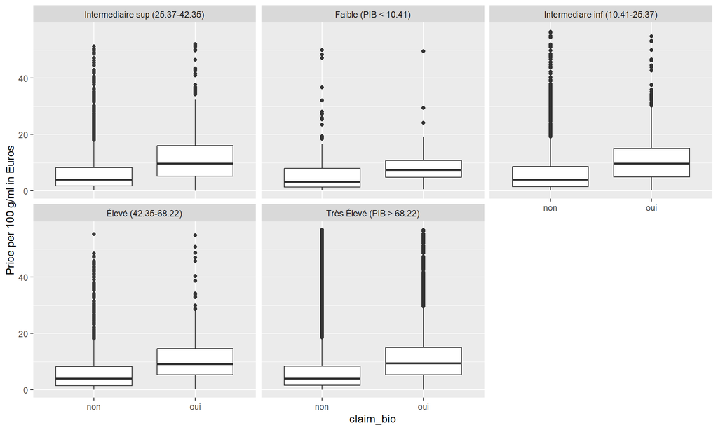

```r
df_tea %>%
  filter(!is.na(`Price per 100 g/ml in Euros`),
         `Price per 100 g/ml in Euros` < quantile(`Price per 100 g/ml in Euros`,
                                                  0.99, na.rm = TRUE)) %>%
  ggplot(aes(x = claim_bio, y = `Price per 100 g/ml in Euros`)) +
    geom_boxplot() +
    facet_wrap(~pib_categorie)
```

## Regression mixte

```r
if (!require("lqmm")) install.packages("lqmm")
library(lqmm)


# Exemple : quantile médian (tau = 0.5), avec effets aléatoires par pays
# D'abord, nettoyez les noms de colonnes pour éviter les problèmes
# names(df_tea) <- make.names(names(df_tea))
# model_lqmm <- lqmm(
#   fixed = Price.per.100.g.ml.in.Euros ~ post2010 + year +
#            Private.Label + claim_sante + claim_naturel + claim_bio + claim_environnement,
#   random = ~ 1,
#   group = Region_Marche,
#   tau = 0.5,
#   na.action = na.exclude,
#   data = df_tea,  # Utiliser le dataframe sans NA
#   control = lqmmControl(method = "df", LP_tol_ll = 1e-5))
```

```r
#summary(model_lqmm)
```

```r
#ranef(model_lqmm)
```